# Airline On-Time Performance Data Exploration

## Introduction

This dataset reports flights in the United States, including carriers, arrival and departure delays, and reasons for delays, from 2005 to 2007

## Preliminary Wrangling

This document explores a dataset containing attributes for approximately 21,000,000 flight report.

```python
# import all packages and set plots to be embedded inline
import numpy as np
import pandas as pd
import matplotlib.pyplot as plt
import seaborn as sb
from datetime import datetime as dt

%matplotlib inline
```

first we will look at the variable descriptions to selected the columns that we are interestin in

```python
var_des = pd.read_csv('variable-descriptions.csv')
var_des
```

|  | Variable descriptions | Unnamed: 1 | Unnamed: 2 |
| --- | --- | --- | --- |
| 0 | NaN | NaN | NaN |
| 1 | NaN | Name | Description |
| 2 | 1.0 | Year | 1987-2008 |
| 3 | 2.0 | Month | 12-Jan |
| 4 | 3.0 | DayofMonth | 31-Jan |
| 5 | 4.0 | DayOfWeek | 1 (Monday) - 7 (Sunday) |
| 6 | 5.0 | DepTime | actual departure time (local, hhmm) |
| 7 | 6.0 | CRSDepTime | scheduled departure time (local, hhmm) |
| 8 | 7.0 | ArrTime | actual arrival time (local, hhmm) |
| 9 | 8.0 | CRSArrTime | scheduled arrival time (local, hhmm) |
| 10 | 9.0 | UniqueCarrier | unique carrier code |
| 11 | 10.0 | FlightNum | flight number |
| 12 | 11.0 | TailNum | plane tail number |
| 13 | 12.0 | ActualElapsedTime | in minutes |
| 14 | 13.0 | CRSElapsedTime | in minutes |
| 15 | 14.0 | AirTime | in minutes |
| 16 | 15.0 | ArrDelay | arrival delay, in minutes |
| 17 | 16.0 | DepDelay | departure delay, in minutes |
| 18 | 17.0 | Origin | origin IATA airport code |
| 19 | 18.0 | Dest | destination IATA airport code |
| 20 | 19.0 | Distance | in miles |
| 21 | 20.0 | TaxiIn | taxi in time, in minutes |
| 22 | 21.0 | TaxiOut | taxi out time in minutes |
| 23 | 22.0 | Cancelled | was the flight cancelled? |
| 24 | 23.0 | CancellationCode | reason for cancellation (A = carrier, B = weat... |
| 25 | 24.0 | Diverted | 1 = yes, 0 = no |
| 26 | 25.0 | CarrierDelay | in minutes |
| 27 | 26.0 | WeatherDelay | in minutes |
| 28 | 27.0 | NASDelay | in minutes |
| 29 | 28.0 | SecurityDelay | in minutes |
| 30 | 29.0 | LateAircraftDelay | in minutes |

now we can choose our variables that we are going to work with

```python
usecol =['Year','Month','DayofMonth','Cancelled','CancellationCode','ActualElapsedTime','CarrierDelay','WeatherDelay','NASDelay','SecurityDelay','ArrDelay','DepDelay','ActualElapsedTime','Diverted','LateAircraftDelay','Origin', 'Dest','Distance']
df5 = pd.read_csv('2005.csv',usecols=usecol)
df6 = pd.read_csv('2006.csv',usecols=usecol)
df7 = pd.read_csv('2007.csv',usecols=usecol)
df = df5.append(df6,ignore_index=True)
df = df.append(df7,ignore_index= True)
```

[output not shown]

```python
# high-level overview of data shape and composition
print(df.shape)
print(df.dtypes)
print(df.head(10))
```

```
(21735733, 17)
Year                   int64
Month                  int64
DayofMonth             int64
ActualElapsedTime    float64
ArrDelay             float64
DepDelay             float64
Origin                object
Dest                  object
Distance               int64
Cancelled              int64
CancellationCode      object
Diverted               int64
CarrierDelay           int64
WeatherDelay           int64
NASDelay               int64
SecurityDelay          int64
LateAircraftDelay      int64
dtype: object
   Year  Month  DayofMonth  ActualElapsedTime  ArrDelay  DepDelay Origin Dest  \
0  2005      1          28              158.0     -18.0      -2.0    BOS  ORD
1  2005      1          29              157.0     -23.0      -6.0    BOS  ORD
2  2005      1          30              158.0     -24.0      -7.0    BOS  ORD
3  2005      1          31              150.0     -33.0      -9.0    BOS  ORD
4  2005      1           2              121.0       3.0      34.0    ORD  BOS
5  2005      1           3              147.0      97.0     102.0    ORD  BOS
6  2005      1           4              131.0      85.0     106.0    ORD  BOS
7  2005      1           5                NaN       NaN       NaN    ORD  BOS
8  2005      1           6              118.0     105.0     130.0    ORD  BOS
9  2005      1           7              156.0      12.0      -1.0    ORD  BOS

   Distance  Cancelled CancellationCode  Diverted  CarrierDelay  WeatherDelay  \
0       867          0              NaN         0             0             0
1       867          0              NaN         0             0             0
2       867          0              NaN         0             0             0
3       867          0              NaN         0             0             0
4       867          0              NaN         0             0             0
5       867          0              NaN         0            23             0
6       867          0              NaN         0            46             0
7       867          1                B         0             0             0
8       867          0              NaN         0            16             0
9       867          0              NaN         0             0             0

   NASDelay  SecurityDelay  LateAircraftDelay
0         0              0                  0
1         0              0                  0
2         0              0                  0
3         0              0                  0
4         0              0                  0
5         0              0                 74
6         0              0                 39
7         0              0                  0
8         0              0                 89
9         0              0                  0
```

```python
# descriptive statistics for numeric variables
print(df.describe())
```

```
               Year         Month    DayofMonth  ActualElapsedTime  \
count  2.173573e+07  2.173573e+07  2.173573e+07       2.127193e+07
mean   2.006014e+03  6.519535e+00  1.572528e+01       1.257125e+02
std    8.192761e-01  3.420429e+00  8.784553e+00       7.110605e+01
min    2.005000e+03  1.000000e+00  1.000000e+00      -6.600000e+01
25%    2.005000e+03  4.000000e+00  8.000000e+00       7.500000e+01
50%    2.006000e+03  7.000000e+00  1.600000e+01       1.070000e+02
75%    2.007000e+03  9.000000e+00  2.300000e+01       1.560000e+02
max    2.007000e+03  1.200000e+01  3.100000e+01       1.879000e+03

           ArrDelay      DepDelay      Distance     Cancelled      Diverted  \
count  2.127193e+07  2.131932e+07  2.173573e+07  2.173573e+07  2.173573e+07
mean   8.705460e+00  1.007372e+01  7.237899e+02  1.915795e-02  2.180419e-03
std    3.681172e+01  3.372605e+01  5.692602e+02  1.370800e-01  4.664402e-02
min   -9.390000e+02 -1.200000e+03  1.100000e+01  0.000000e+00  0.000000e+00
25%   -9.000000e+00 -4.000000e+00  3.170000e+02  0.000000e+00  0.000000e+00
50%   -1.000000e+00  0.000000e+00  5.690000e+02  0.000000e+00  0.000000e+00
75%    1.300000e+01  9.000000e+00  9.500000e+02  0.000000e+00  0.000000e+00
max    2.598000e+03  2.601000e+03  4.962000e+03  1.000000e+00  1.000000e+00

       CarrierDelay  WeatherDelay      NASDelay  SecurityDelay  \
count  2.173573e+07  2.173573e+07  2.173573e+07   2.173573e+07
mean   3.427794e+00  7.042450e-01  3.582012e+00   2.481269e-02
std    1.917172e+01  8.841970e+00  1.556168e+01   1.133373e+00
min    0.000000e+00  0.000000e+00 -4.900000e+01   0.000000e+00
25%    0.000000e+00  0.000000e+00  0.000000e+00   0.000000e+00
50%    0.000000e+00  0.000000e+00  0.000000e+00   0.000000e+00
75%    0.000000e+00  0.000000e+00  0.000000e+00   0.000000e+00
max    2.580000e+03  1.510000e+03  1.392000e+03   3.820000e+02

       LateAircraftDelay
count       2.173573e+07
mean        4.435478e+00
std         1.962606e+01
min         0.000000e+00
25%         0.000000e+00
50%         0.000000e+00
75%         0.000000e+00
max         1.366000e+03
```

next instead of cancellation code it would be more clear if we use the actual reason

```python
cancel_reson = {'A':'carrier','B':'weather','C':'NAS','D':'security'}
df['CancellationCode'] = df['CancellationCode'].fillna('None')
df['CancelReason'] = df['CancellationCode'].replace(cancel_reson.keys(),cancel_reson.values()).astype('category')
```

after choosing our vairble we will load the airport file so we can use the city variable

```python
airports = pd.read_csv('airports.csv')
airports.head()
```

|  | iata | airport | city | state | country | lat | long |
| --- | --- | --- | --- | --- | --- | --- | --- |
| 0 | 00M | Thigpen | Bay Springs | MS | USA | 31.953765 | -89.234505 |
| 1 | 00R | Livingston Municipal | Livingston | TX | USA | 30.685861 | -95.017928 |
| 2 | 00V | Meadow Lake | Colorado Springs | CO | USA | 38.945749 | -104.569893 |
| 3 | 01G | Perry-Warsaw | Perry | NY | USA | 42.741347 | -78.052081 |
| 4 | 01J | Hilliard Airpark | Hilliard | FL | USA | 30.688012 | -81.905944 |

```python
# we will use the iata as a prime key to join the city variable to our dateframe
# we will join for both orgin city and destaintaion city
org = airports[['iata','city']].rename(columns={'iata':'Origin','city':'OriginCity'})
dest = airports[['iata','city']].rename(columns={'iata':'Dest','city':'DestCity'})
df = df.merge(org, on='Origin')
df = df.merge(dest, on='Dest')
df['OriginCity']=df['OriginCity']
df['DestCity']=df['DestCity']
#after finishing we can get rid of the iata code to save more space
df.drop(['Origin','Dest'],axis =1,inplace = True)
df
```

|  | Year | Month | DayofMonth | ActualElapsedTime | ArrDelay | DepDelay | Distance | Cancelled | CancellationCode | Diverted | CarrierDelay | WeatherDelay | NASDelay | SecurityDelay | LateAircraftDelay | CancelReason | OriginCity | DestCity |
| --- | --- | --- | --- | --- | --- | --- | --- | --- | --- | --- | --- | --- | --- | --- | --- | --- | --- | --- |
| 0 | 2005 | 1 | 28 | 158.0 | -18.0 | -2.0 | 867 | 0 | None | 0 | 0 | 0 | 0 | 0 | 0 | None | Boston | Chicago |
| 1 | 2005 | 1 | 29 | 157.0 | -23.0 | -6.0 | 867 | 0 | None | 0 | 0 | 0 | 0 | 0 | 0 | None | Boston | Chicago |
| 2 | 2005 | 1 | 30 | 158.0 | -24.0 | -7.0 | 867 | 0 | None | 0 | 0 | 0 | 0 | 0 | 0 | None | Boston | Chicago |
| 3 | 2005 | 1 | 31 | 150.0 | -33.0 | -9.0 | 867 | 0 | None | 0 | 0 | 0 | 0 | 0 | 0 | None | Boston | Chicago |
| 4 | 2005 | 1 | 1 | 195.0 | 4.0 | -11.0 | 867 | 0 | None | 0 | 0 | 0 | 0 | 0 | 0 | None | Boston | Chicago |
| ... | ... | ... | ... | ... | ... | ... | ... | ... | ... | ... | ... | ... | ... | ... | ... | ... | ... | ... |
| 21735728 | 2007 | 12 | 27 | 19.0 | -26.0 | -17.0 | 31 | 0 | None | 0 | 0 | 0 | 0 | 0 | 0 | None | Petersburg | Wrangell |
| 21735729 | 2007 | 12 | 28 | 27.0 | -5.0 | -4.0 | 31 | 0 | None | 0 | 0 | 0 | 0 | 0 | 0 | None | Petersburg | Wrangell |
| 21735730 | 2007 | 12 | 29 | 24.0 | 5.0 | 9.0 | 31 | 0 | None | 0 | 0 | 0 | 0 | 0 | 0 | None | Petersburg | Wrangell |
| 21735731 | 2007 | 12 | 30 | 26.0 | -31.0 | -29.0 | 31 | 0 | None | 0 | 0 | 0 | 0 | 0 | 0 | None | Petersburg | Wrangell |
| 21735732 | 2007 | 12 | 31 | 17.0 | -13.0 | -2.0 | 31 | 0 | None | 0 | 0 | 0 | 0 | 0 | 0 | None | Petersburg | Wrangell |

21735733 rows × 18 columns

```python
time  = ['ArrDelay','DepDelay','ActualElapsedTime','ActualElapsedTime','CarrierDelay','WeatherDelay','NASDelay','SecurityDelay','LateAircraftDelay']
for var in time:
    df[var] = df[var].fillna(0)
```

we will sum the the delytime to only one column called TotalDelay to save more space also reduce the number of columns

```python
delay = df.loc[:,'CarrierDelay':'LateAircraftDelay']
df['TotalDelay'] = delay.sum(axis =1)
df.drop(delay.columns,axis =1,inplace = True)
```

```python
YMD = ['Year','Month','DayofMonth']
# first we will convert to string so we can put them in datetime format
for dt in YMD:
    df[dt] = df[dt].astype('str')
df['Date']=df['DayofMonth'] +'-'+ df['Month'] + '-' + df['Year']
# after putting the 3 columns in a datetime format now we can convert them to datetime object
df['Date'] = pd.to_datetime(df['Date'])
df.drop(YMD,axis =1,inplace = True)
# finally we remove the all of the 3 columns
```

[output not shown]

[output cut: 281 more lines]

[output not shown]

then we will conver the Diverted and Cancelled Columns to boolean so we can work with them more easily

```python
bool = ['Diverted','Cancelled']
for var in bool:
    df[var] = df[var].replace([0,1],[False,True])
```

after than we will choose the final variable the we will explore

```python
df =df[['Date','Cancelled','CancelReason','TotalDelay','ArrDelay','DepDelay','ActualElapsedTime','OriginCity', 'DestCity','Diverted','Distance']].dropna()
df
```

|  | Date | Cancelled | CancelReason | TotalDelay | ArrDelay | DepDelay | ActualElapsedTime | OriginCity | DestCity | Diverted | Distance |
| --- | --- | --- | --- | --- | --- | --- | --- | --- | --- | --- | --- |
| 0 | 2005-01-28 | False | None | 0 | -18.0 | -2.0 | 158.0 | Boston | Chicago | False | 867 |
| 1 | 2005-01-29 | False | None | 0 | -23.0 | -6.0 | 157.0 | Boston | Chicago | False | 867 |
| 2 | 2005-01-30 | False | None | 0 | -24.0 | -7.0 | 158.0 | Boston | Chicago | False | 867 |
| 3 | 2005-01-31 | False | None | 0 | -33.0 | -9.0 | 150.0 | Boston | Chicago | False | 867 |
| 4 | 2005-01-01 | False | None | 0 | 4.0 | -11.0 | 195.0 | Boston | Chicago | False | 867 |
| ... | ... | ... | ... | ... | ... | ... | ... | ... | ... | ... | ... |
| 21735728 | 2007-12-27 | False | None | 0 | -26.0 | -17.0 | 19.0 | Petersburg | Wrangell | False | 31 |
| 21735729 | 2007-12-28 | False | None | 0 | -5.0 | -4.0 | 27.0 | Petersburg | Wrangell | False | 31 |
| 21735730 | 2007-12-29 | False | None | 0 | 5.0 | 9.0 | 24.0 | Petersburg | Wrangell | False | 31 |
| 21735731 | 2007-12-30 | False | None | 0 | -31.0 | -29.0 | 26.0 | Petersburg | Wrangell | False | 31 |
| 21735732 | 2007-12-31 | False | None | 0 | -13.0 | -2.0 | 17.0 | Petersburg | Wrangell | False | 31 |

21706733 rows × 11 columns

finally we will save the dateframe to a csv file so we can directely work with the cleaned data next time

```python
df.to_csv('2005-2007.csv',index=False)
```

### What is the structure of your dataset?

There are 21,706,733 flight report in the dataset with 11 features (cDate,Cancelled,CancelReason,TotalDelay,ArrDelay DepDelay,ActualElapsedTime,OriginCity,DestCity,Diverted,Distance). some variables are numeric in nature like TotalDely Distance,... , and the variables DestCity, OriginCity,CancelReason are categorical ,also the variables cancelled and Diverted is boolean variables and finally the Date is datetime variable

### What is/are the main feature(s) of interest in your dataset?

I'm most interested in figuring out which cities have make more from/to flights and also the reasons for delayed and cancelled flights

### What features in the dataset do you think will help support your investigation into your feature(s) of interest?

I expect that TotalDelay will help me to figure the most citits with the number of delayed flights also the the range of delyation time for the flights for each city also the Date variable would help me to see the variation during the period from 2005 to 2007 also the Distance will help me to se if there is a relation between delayed and cancelled flights and the distacne between the two ciites finally the CancellReason variable will help me to figure out the most reason for flight cancellations

## Univariate Exploration

I'll start by looking at the cancellation reason for the cancelled flights.

```python
# we will sort the cities due to their number of cancelled flights
cancelled_cities = df.groupby('DestCity').sum()['Cancelled'].sort_values(ascending = False)
order = cancelled_cities.index
cancelled_df = df[df['Cancelled']==True]
cancelled_flights = cancelled_df['DestCity'].reset_index().drop('index',axis =1)
```

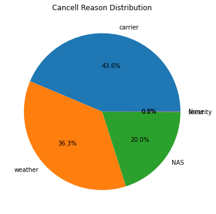

```python
my_data = cancelled_df['CancelReason'].value_counts()
my_labels = cancelled_df['CancelReason'].value_counts().index
plt.figure(figsize = (8,6))
plt.pie(my_data, labels=my_labels, autopct='%1.1f%%')
plt.title('Cancell Reason Distribution')
plt.show()
```

it's clear that most of cancellation is due to the carrier problems and the security is the least of them

##### now we will look at the distribution of the cities accoding their number of cancelled flight

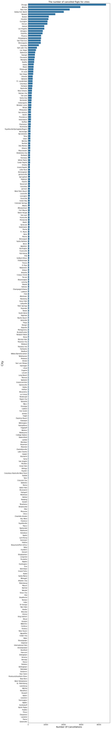

```python
plt.figure(figsize =(10,90))
base_color = sb.color_palette()[0]
sb.countplot(data = cancelled_flights,y = 'DestCity',order = order, color = base_color)
plt.title('The number of cancelled fligts for cities',fontsize=14)
plt.ylabel('City',fontsize=18)
plt.xlabel('Number Of Cancellations',fontsize=14)
plt.show()
```

instead of dealing with all citites we will foucs on the top 10 cites from now and on so it can render more fast

```python
cancelled_flights_df=df.groupby('DestCity').sum()
cancelled_flights = cancelled_flights_df['Cancelled'].sort_values(ascending = False)
top_citites= cancelled_flights.head(10)
top_citites = top_citites.reset_index()
order =top_citites['DestCity']
order = list(order)
top_cancelled_df = cancelled_df[cancelled_df['DestCity'].isin(order)]
cancelled_flights = df[df['Cancelled']==True]['DestCity'].reset_index().drop('index',axis =1)
cancelled_flights =cancelled_flights[cancelled_flights['DestCity'].isin(order)]
```

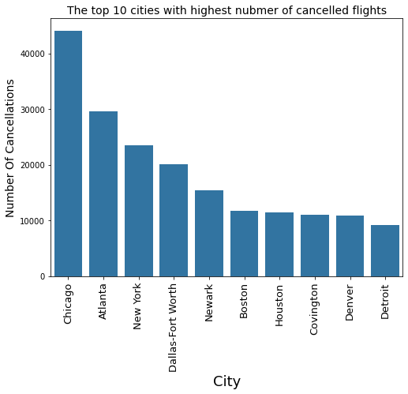

```python
plt.figure(figsize=(8,6))
sb.countplot(data = cancelled_flights,x = 'DestCity',order = order, color = base_color)
plt.xticks(rotation = 90,fontsize=13)
plt.title('The top 10 cities with highest nubmer of cancelled flights',fontsize=14)
plt.xlabel('City',fontsize=18)
plt.ylabel('Number Of Cancellations',fontsize=14)
plt.show()
```

it's clear that Chicago has the higheset number of cancelled flights

#### next will will take a look the cities with highest nubmer of delyed flights

```python
# by the same way we use groupby to sort the cities acording their number of delyed flights
delayed_flights = df[df['TotalDelay']>0]
delayed_cities = delayed_flights.groupby('DestCity').count()['TotalDelay'].sort_values(ascending = False)
top_delayed_citites= delayed_cities.head(10)
top_delayed_citites = top_delayed_citites.reset_index()
order =top_delayed_citites['DestCity']
order = list(order)
delayed_flights =delayed_flights[delayed_flights['DestCity'].isin(order)]
```

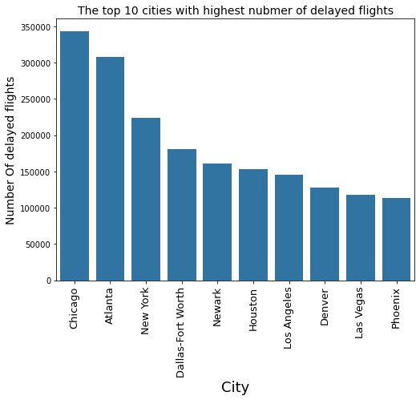

```python
plt.figure(figsize=(8,6))
sb.countplot(data = delayed_flights,x = 'DestCity',order = order, color = base_color)
plt.xticks(rotation = 90,fontsize=13)
plt.title('The top 10 cities with highest nubmer of delayed flights',fontsize=14)
plt.xlabel('City',fontsize=18)
plt.ylabel('Number Of delayed flights',fontsize=14)
plt.show()
```

#### also it seems that Chicago has the higest number of delyed flights too

### by the way let's take a look to see the distriubtion of the delayed flights reasons

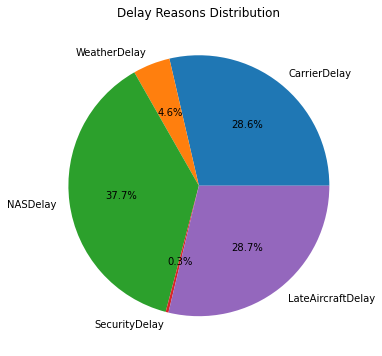

```python
delay_reason = (delay.replace(0,np.NaN).isna()==False).sum()
my_data = delay_reason.values
my_labels = delay_reason.index
plt.figure(figsize = (8,6))
plt.pie(my_data, labels=my_labels, autopct='%1.1f%%')
plt.title('Delay Reasons Distribution')
plt.show()
```

#### we can see that NASDelay is the most common Delay Reason and SecurityDealy is the leastone

### let's see which cities have more cities in USA during the period from 2005 to 2007

```python
visited_df = df.groupby('DestCity').count()
vistied_cities = visited_df['Distance'].sort_values(ascending = False)
top_citites= vistied_cities.head(10)
top_citites = top_citites.reset_index()
order =top_citites['DestCity']
order = list(order)
```

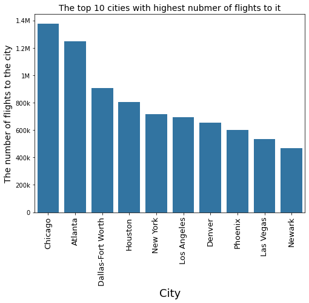

```python
plt.figure(figsize=(8,6))
sb.countplot(data = df,x = 'DestCity',order = order, color = base_color)
plt.xticks(rotation = 90,fontsize=13)
plt.title('The top 10 cities with highest nubmer of flights to it',fontsize=14)
plt.xlabel('City',fontsize=18)
plt.ylabel('The number of flights to the city',fontsize=14)
y_ticks = np.arange(0,1.4e6+2e5,2e5)
y_tick_labels = ['0','200k','400k','600k','800k','1M','1.2M','1.4M']
plt.yticks(y_ticks,y_tick_labels)
plt.show()
```

#### we can see that Chiago and Atlanta have the most number of vitits

### now let's move to the numeric variables and strat with the distribution of the Dely time for all flights

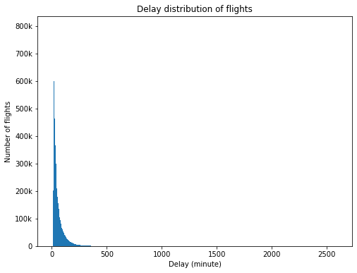

```python
bins = np.arange(1,df['TotalDelay'].max()+5,5)
plt.figure(figsize = (8,6))
plt.hist(data = df, x = 'TotalDelay',bins = bins)
y_ticks = np.arange(0,8e5+1e5,1e5)
y_labels = ['0','100k','200k','300k','400k','500k','600k','700k','800k']
plt.yticks(y_ticks, y_labels)
plt.xlabel('Delay (minute)')
plt.ylabel('Number of flights')
plt.title('Delay distribution of flights')
plt.show()
```

#### it'clear that the distribution is right skweded and also it seems that there are an outliers between 500 and 300 minutes so we will focus on the first 100 mintues as the most of data lies below

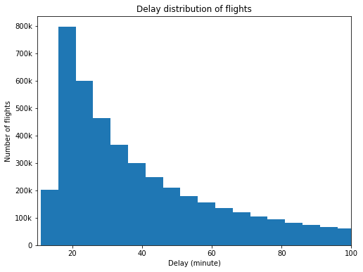

```python
bins = np.arange(1,df['TotalDelay'].max()+5,5)
plt.figure(figsize = (8,6))
plt.hist(data = df, x = 'TotalDelay',bins = bins)
x_ticks = np.arange(0,100+20,20)
plt.xticks(x_ticks,x_ticks)
y_ticks = np.arange(0,8e5+1e5,1e5)
y_labels = ['0','100k','200k','300k','400k','500k','600k','700k','800k']
plt.yticks(y_ticks, y_labels)
plt.xlabel('Delay (minute)')
plt.ylabel('Number of flights')
plt.xlim(10,100)
plt.title('Delay distribution of flights')
plt.show()
```

#### it seems that most delayations lie between 20 and 40 minutes

### next lets move to see the distribution of the disance for all flights

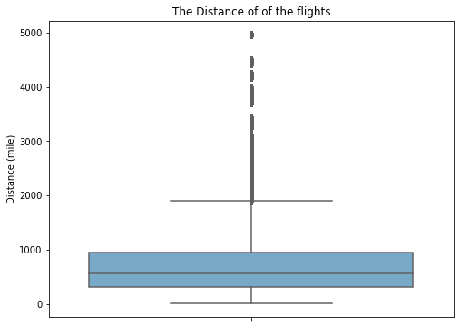

```python
plt.figure(figsize = (8,6))
sb.boxplot(data = df, y = 'Distance',  palette = 'Blues')
plt.ylabel('Distance (mile)')
plt.title('The Distance of of the flights')
plt.show()
```

#### we can see that most of fligts is below 1000 mile so will foucs on the distribution of filghts that less than 1000 miles

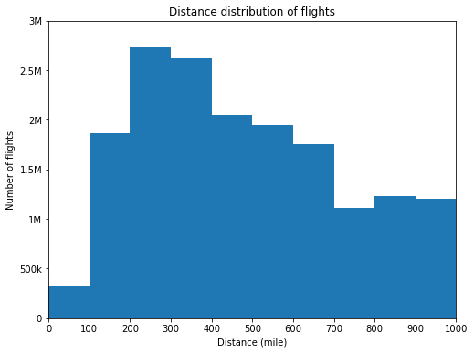

```python
bins = np.arange(0,df['Distance'].max()+100,100)
plt.figure(figsize = (8,6))
plt.hist(data = df, x = 'Distance',bins = bins)
x_ticks = np.arange(0,1000+100,100)
plt.xticks(x_ticks,x_ticks)
y_ticks = np.arange(0,3e6+5e5,5e5)
y_labels = ['0','500k','1M','1.5M','2M','2.5M','3M']
plt.yticks(y_ticks,y_labels)
plt.xlabel('Distance (mile)')
plt.ylabel('Number of flights')
plt.title('Distance distribution of flights')
plt.xlim(0,1000)
plt.show()
```

#### according to the distribution most filghts distances are laying between 200 and 700 miles

### finally let's see the distriubtion of the elapsed time

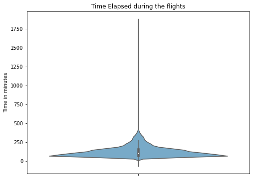

```python
plt.figure(figsize = (8,6))
sb.violinplot(data = df, y = 'ActualElapsedTime',  palette = 'Blues')
plt.title('Time Elapsed during the flights')
plt.ylabel('Time in minutes')
plt.show()
```

#### we can see that most of flights are laying below 250 minutes also it seems that there are outliers above than 1750 minutes

```python
df[df['ActualElapsedTime']>1750]['TotalDelay']
```

```
1774247     415
5660669     880
5661727     249
5687331     263
5710367     293
5717972     266
5718375     313
5718790     389
5785185     855
5862619     303
10480878    260
10846302    404
11708665    300
11708667    307
12657192    278
```

[output cut: 17 more lines]

as we see that ouliers have high Delay that leaded to that high elapsed time

### now let's foucs on the flights that below than 250 minutes

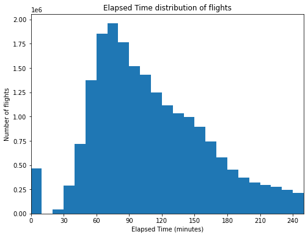

```python
bins = np.arange(0,df['ActualElapsedTime'].max()+10,10)
plt.figure(figsize = (8,6))
plt.hist(data = df, x = 'ActualElapsedTime',bins = bins)
x_ticks = np.arange(0,250+30,30)
y_labels = ['0','500k','1M','1.5M','2M','2.5M','3M']
plt.xticks(x_ticks,x_ticks)
plt.xlim(0,250)
plt.xlabel('Elapsed Time (minutes)')
plt.ylabel('Number of flights')
plt.title('Elapsed Time distribution of flights')
plt.show()
```

#### now we can see that most of flighs take time between 60-120 minuts (1-2) hours

### and now we can use the Date variable to see the numer of flights distributions acording to (year-month-day of the week)

```python
#first we will use the Date variable to get the year , month and the day name
date = df['Date'].dt.day_name().reset_index()
date['Day'] = date['Date']
date['Month'] = df['Date'].dt.month_name()
date['Year'] = df['Date'].dt.year
date = date.dropna()
date['Year'] = date['Year'].astype(int)
date = date[['Day','Month','Year']]
date.head()
```

|  | Day | Month | Year |
| --- | --- | --- | --- |
| 0 | Friday | January | 2005 |
| 1 | Saturday | January | 2005 |
| 2 | Sunday | January | 2005 |
| 3 | Monday | January | 2005 |
| 4 | Saturday | January | 2005 |

```python
y_ticks = [np.arange(0,3e6+5e5,5e5),np.arange(0,1.75e6+2.5e5,2.5e5),np.arange(0,7e6+1e6,1e6)]
y_ticks_label = [
                    ['0','500k','1M','1.5M','2M','2.5M','3M'],
                    ['0','250k','500k','750k','1M','1.25M','1.5M','1.75M'],
                    ['0','1M','2M','3M','4M','5M','6M','7M']
                ]
```

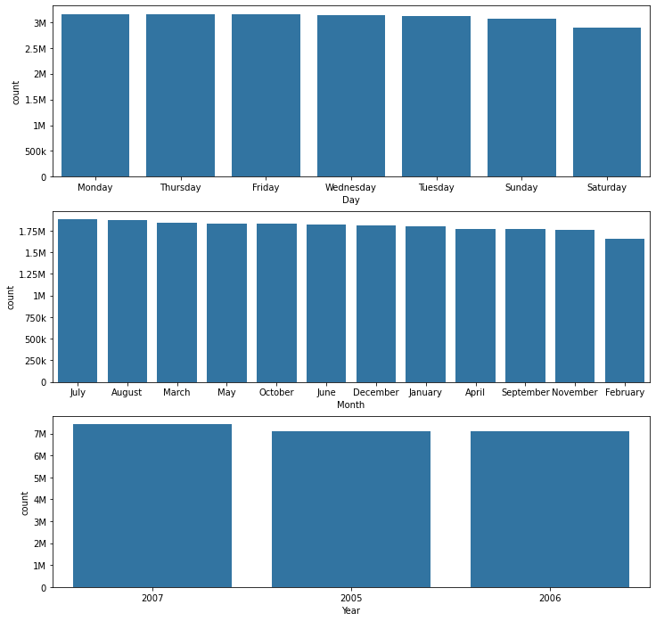

```python
fig, ax = plt.subplots(nrows=3, figsize = [12,12])
for i, var in enumerate(date.columns):
    sb.countplot(data = date, x = var , color = base_color, ax = ax[i] ,order = date[var].value_counts().index)
    ax[i].set_yticks(y_ticks[i])
    ax[i].set_yticklabels(y_ticks_label[i])
plt.show()
```

#### tho plot shows that weekdays have slightly more flights than the weekends also it's almost the same the between monthes maybe Febraury have less flights as it has only 28 days and also it's almost the same for years all around 7 million flights per year

### Discuss the distribution(s) of your variable(s) of interest. Were there any unusual points? Did you need to perform any transformations?

the DestCity variable shows that Chiago has the most number of delyed flights, cancelled flights and also have the most vistied during all the cities

### Of the features you investigated, were there any unusual distributions? Did you perform any operations on the data to tidy, adjust, or change the form of the data? If so, why did you do this?

the data is almost nature maybe there are some weird outliers in some variable but it's still acceptable values, but for the countruction of the dataframe we did some cleaning process in order to be able to reduce the number of columns and that will will save more memory in it's turn

## Bivariate Exploration

To start off with, I want to look at the pairwise correlations present between features in the data

```python
numeric_vars = ['TotalDelay','ArrDelay','DepDelay','Distance','ActualElapsedTime']
categoric_vars = ['Cancelled', 'CancelReason', 'OriginCity','DestCity']
```

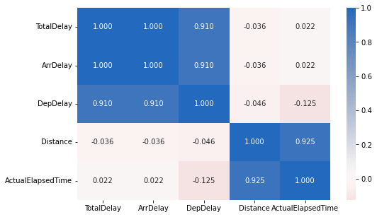

```python
plt.figure(figsize = [8, 5])
sb.heatmap(delayed_flights[numeric_vars].corr(), annot = True, fmt = '.3f',
           cmap = 'vlag_r', center = 0)
plt.show()
```

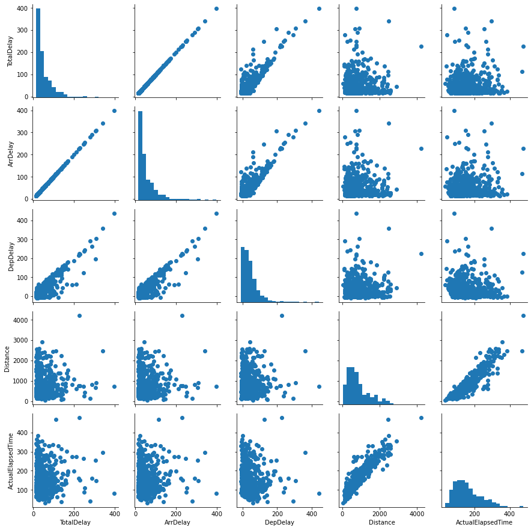

```python
# plot matrix: sample 500 flights so that plots are clearer and
# they render faster
samples = np.random.choice(delayed_flights.shape[0], 500, replace = False)
flights_samp = delayed_flights.iloc[samples,:]

g = sb.PairGrid(data = flights_samp, vars = numeric_vars)
g = g.map_diag(plt.hist, bins = 20);
g.map_offdiag(plt.scatter);
```

As expected, the ''TotalDelay','ArrDelay'and'DepDelay' are all highly correlated with one another, also 'Distance' and 'ActualElapsedTime' is higly correlated

Surprisingly, 'TotalDelay' and 'ActualElapsedTime' isn't correlated with each other

### now let's see the correlations between the different delays time

```python
delayed = delay.copy()
for var in delay.columns:
    delayed[var] = delay[var].replace(0,np.nan)
delayed = delayed.dropna(how = 'all')
delayed = delayed.fillna(0)
delayed
```

|  | CarrierDelay | WeatherDelay | NASDelay | SecurityDelay | LateAircraftDelay |
| --- | --- | --- | --- | --- | --- |
| 6 | 0.0 | 0.0 | 111.0 | 0.0 | 0.0 |
| 7 | 0.0 | 0.0 | 35.0 | 0.0 | 0.0 |
| 9 | 0.0 | 0.0 | 199.0 | 0.0 | 0.0 |
| 10 | 0.0 | 0.0 | 24.0 | 0.0 | 0.0 |
| 11 | 0.0 | 0.0 | 156.0 | 0.0 | 0.0 |
| ... | ... | ... | ... | ... | ... |
| 21735697 | 0.0 | 0.0 | 1.0 | 0.0 | 250.0 |
| 21735712 | 0.0 | 0.0 | 20.0 | 0.0 | 0.0 |
| 21735716 | 0.0 | 0.0 | 0.0 | 0.0 | 33.0 |
| 21735723 | 0.0 | 0.0 | 0.0 | 0.0 | 35.0 |
| 21735724 | 0.0 | 0.0 | 0.0 | 0.0 | 36.0 |

4884922 rows × 5 columns

```python
numeric_vars = list(delayed.columns)
```

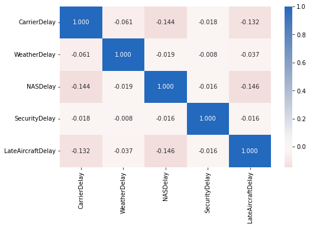

```python
plt.figure(figsize = [8, 5])
sb.heatmap(delayed[numeric_vars].corr(), annot = True, fmt = '.3f',
           cmap = 'vlag_r', center = 0)
plt.show()
```

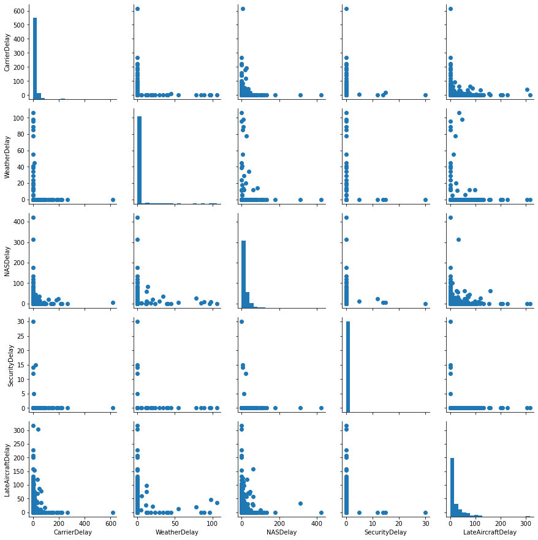

```python
# plot matrix: sample 500 diamonds so that plots are clearer and
# they render faster
samples = np.random.choice(delayed.shape[0], 500, replace = False)
delays_samp = delayed.iloc[samples,:]
g = sb.PairGrid(data = delays_samp, vars = numeric_vars)
g = g.map_diag(plt.hist, bins = 20);
g.map_offdiag(plt.scatter);
```

#### it's seem that there is no obvious relation between any of them

#### now we will try to figure if there is a relation between the number of delayed flights to the number of cancelled flights for each city

```python
no_del_flights = delayed_cities.reset_index()
no_cancel_flights =cancelled_flights_df['Cancelled'].sort_values(ascending = False).reset_index()
delay2cancel = no_del_flights.merge(no_cancel_flights, on='DestCity')
```

[figure not shown]

```python
plt.figure(figsize = [8, 6])
plt.scatter(data = delay2cancel, x = 'TotalDelay', y = 'Cancelled')
plt.title('the relationship between the number of cancelled flights  to the number of Delayed flights for each city')
plt.xlabel('number of cancelled flights')
plt.ylabel('number of Delayed flights')
plt.show()
```

as we can see there is a positive correlation between the number of Delyed flights and the number of Cancelled flights and maybe this because that cities with high number of delayed flights maybe is less prepared or has high work pressaure so that they tend to have more cancelled flights

### now let's see the realation between the Distance to the total Delay for each flight

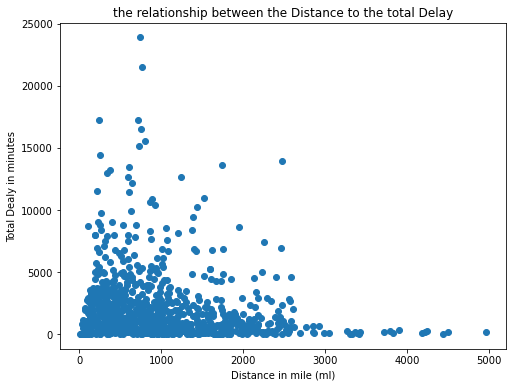

```python
distance2delay= delayed_flights.groupby('Distance').count()['TotalDelay'].reset_index()
plt.figure(figsize = [8, 6])
plt.scatter(data = distance2delay, x = 'Distance', y = 'TotalDelay')
plt.title('the relationship between the Distance to the total Delay')
plt.xlabel('Distance in mile (ml)')
plt.ylabel('Total Dealy in minutes')
plt.show()
```

### now let's take a look at the main resons for cancelled flights

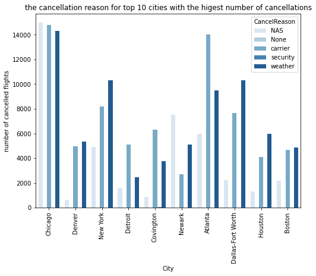

```python
def cancel_reason():
    plt.figure(figsize = (8,6))
    sb.countplot(data = top_cancelled_df, x = 'DestCity', hue = 'CancelReason', palette = 'Blues')
    plt.xticks(rotation = 90)
    plt.title('the cancellation reason for top 10 cities with the higest number of cancellations')
    plt.xlabel('City')
    plt.ylabel('number of cancelled flights')
    plt.show()
cancel_reason()
```

##### It seems that Chicago has the most number of cancelled flights but as we see before that Chicago has the most number of vistis so maybe that led to had the most number of them so instead we will look at the ratio of cancellation to the number of visits

```python
cancelled_ratio = (cancelled_flights_df['Cancelled'] /visited_df['Cancelled']).sort_values(ascending = False)
```

```python
cancelled_ratio.head(10).index
```

```
Index(['Nantucket', 'Waterloo', 'Bemidji', 'Sioux City', 'Eau Claire',
       'International Falls', 'Rhinelander', 'Aspen', 'Visalia', 'Telluride'],
      dtype='object', name='DestCity')
```

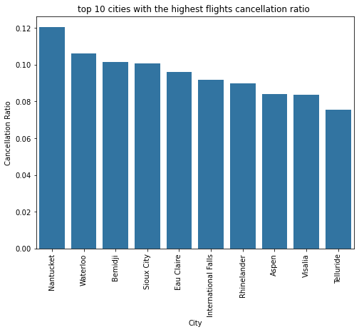

```python
def cancel_ratio():
    plt.figure(figsize = (8,6))
    sb.barplot(x =cancelled_ratio.head(10).index, y = cancelled_ratio.head(10).values, color = base_color)
    plt.xticks(rotation = 90)
    plt.title('top 10 cities with the highest flights cancellation ratio ')
    plt.xlabel('City')
    plt.ylabel('Cancellation Ratio')
    plt.show()
cancel_ratio()
```

it seems that Nantucket the highest cancellation ratio with 12% now let's take a look the top reason of their high cancellation ratio

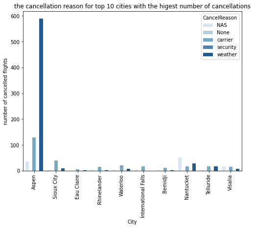

```python
top_cancelled_df = cancelled_df[cancelled_df['DestCity'].isin(cancelled_ratio.head(10).index)]
cancel_reason()
```

seems that most of these cities have really small number of cancelled flights so we will look at their number of visits

```python
df[df['DestCity'].isin(cancelled_ratio.head(10).index)].groupby('DestCity').count()
```

| DestCity | Date | Cancelled | CancelReason | TotalDelay | ArrDelay | DepDelay | ActualElapsedTime | OriginCity | Diverted | Distance |
| --- | --- | --- | --- | --- | --- | --- | --- | --- | --- | --- |
| Aspen | 8966 | 8966 | 8966 | 8966 | 8966 | 8966 | 8966 | 8966 | 8966 | 8966 |
| Bemidji | 128 | 128 | 128 | 128 | 128 | 128 | 128 | 128 | 128 | 128 |
| Eau Claire | 73 | 73 | 73 | 73 | 73 | 73 | 73 | 73 | 73 | 73 |
| International Falls | 218 | 218 | 218 | 218 | 218 | 218 | 218 | 218 | 218 | 218 |
| Nantucket | 781 | 781 | 781 | 781 | 781 | 781 | 781 | 781 | 781 | 781 |
| Rhinelander | 223 | 223 | 223 | 223 | 223 | 223 | 223 | 223 | 223 | 223 |
| Sioux City | 536 | 536 | 536 | 536 | 536 | 536 | 536 | 536 | 536 | 536 |
| Telluride | 489 | 489 | 489 | 489 | 489 | 489 | 489 | 489 | 489 | 489 |
| Visalia | 455 | 455 | 455 | 455 | 455 | 455 | 455 | 455 | 455 | 455 |
| Waterloo | 302 | 302 | 302 | 302 | 302 | 302 | 302 | 302 | 302 | 302 |

as we can see they have really a small number of flights so we can really depend on them to make our conclousions. so instead we will see the ratio for those cities that have at least 1000 visits so we can some how make a reliable concolusion based on them

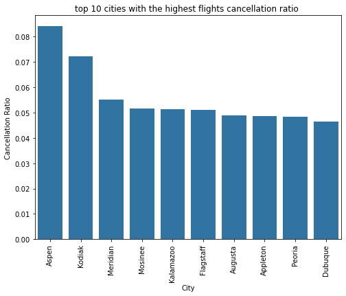

```python
cancelled_ratio = (cancelled_flights_df[visited_df['Cancelled']>1000]/visited_df[visited_df['Cancelled']>1000])['Cancelled'].sort_values(ascending =False)
cancel_ratio()
```

now we can see that Aspen has the highest ratio of cancelled flights now let's the top reason for this high ratio of cancellation

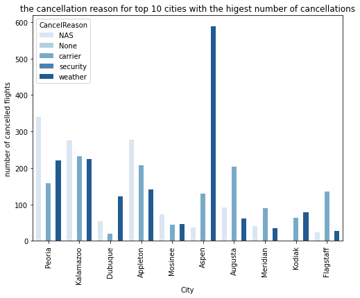

```python
top_cancelled_df = cancelled_df[cancelled_df['DestCity'].isin(cancelled_ratio.head(10).index)]
cancel_reason()
```

#### we can see that the weather proplems is the most common problem of cancellation so now we can see the number of cancellation across the monthes of the year to see if the winter monthes have the highest number of cancellation flights due to its bad weather

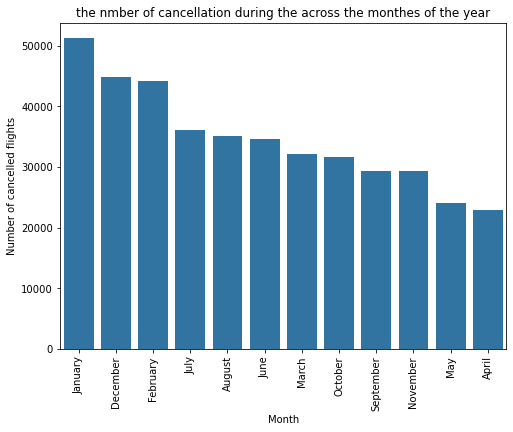

```python
plt.figure(figsize = (8,6))
sb.barplot(x =cancel_month.index, y = cancel_month.values, color = base_color,order= cancel_month.index)
plt.title('the nmber of cancellation during the across the monthes of the year')
plt.xticks(rotation = 90)
plt.xlabel('Month')
plt.ylabel('Number of cancelled flights')
plt.show()
```

#### indeed the winter monthes have the highest number of cancelled flights and as we see that january is highest one and as we know that january is the coldest month and has worest weather in the year

### as we saw that the weather played a big role in the cancelled flights now let's say also if the the distance also play a role in the flights cancellations

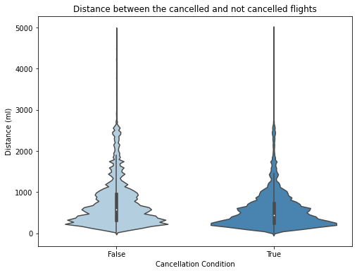

```python
plt.figure(figsize = [8, 6])
sb.violinplot(data = df, y = 'Distance', x = 'Cancelled', palette = 'Blues')
plt.title('Distance between the cancelled and not cancelled flights')
plt.xlabel('Cancellation Condition')
plt.ylabel('Distance (ml)')
plt.show()
```

in constrat to the weather we can see that in long distances there is few cancelled flights as we can see the cancelled tend to occur in the short distances and maybe as we said before that the long flights have to be well prepared

#### now let's see also if the distance palyed a role with diverted flights

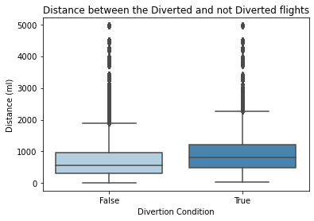

```python
sb.boxplot(data = df, y = 'Distance' ,x='Diverted',  palette = 'Blues')
plt.title('Distance between the Diverted and not Diverted flights')
plt.xlabel('Divertion Condition')
plt.ylabel('Distance (ml)')
plt.show()
```

It seems that the divertions tend to happen in long distances during the long flights if the flight faced a problems for examble bad weather it tend to diverage and change this destaintion rather than cancel the flight

now let's see if the delay time has reduced during the years

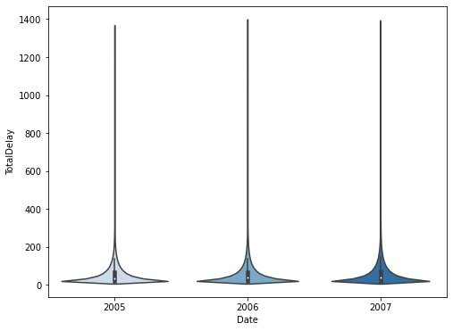

```python
plt.figure(figsize = [8, 6])
sb.violinplot(data = delayed_flights, y = 'TotalDelay', x = df['Date'].dt.year, palette = 'Blues')
plt.show()
```

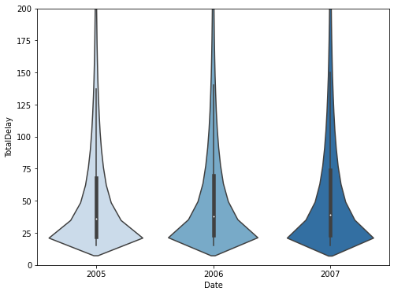

```python
plt.figure(figsize = [8, 6])
sb.violinplot(data = delayed_flights, y = 'TotalDelay', x = df['Date'].dt.year, palette = 'Blues')
plt.ylim(0,200)
plt.show()
```

seem that nothing has changed and most of delay time still in somehow acceptable range around 25 mintues

### finally let's where were the most of flights between wich cititis during the period from 2005-2007

```python
# let see the top six origin and destnation cities
top_cities = df['OriginCity'].value_counts().head(6).index.sort_values()
print(top_cities)
df['DestCity'].value_counts().head(6).index.sort_values()
```

```
Index(['Atlanta', 'Chicago', 'Dallas-Fort Worth', 'Houston', 'Los Angeles',
       'New York'],
      dtype='object')
```

```
Index(['Atlanta', 'Chicago', 'Dallas-Fort Worth', 'Houston', 'Los Angeles',
       'New York'],
      dtype='object')
```

#### it seems that the top 6 in both are the same so we are going to foucs only on the flights between thoose cities

```python
# first let's choose the flights between only the top 6 citites
most_flights = df[(df['OriginCity'].isin(top_cities)) &(df['DestCity'].isin(top_cities)) ]
# now let's sort the cities acording to their names
most_flights= most_flights.groupby(['OriginCity','DestCity']).count().sort_values(by= ['OriginCity','DestCity'])['Distance'].reset_index()
most_flights.rename(columns ={'Distance':'NoOfFlights'},inplace= True)
# now let's fix the missed flights so if cities have no flights between itself so we simply put 0 in the number of the flights
mised_citties= most_flights['OriginCity'].value_counts()[(most_flights['OriginCity'].value_counts()<6)].index
for city in mised_citties:
    most_flights.loc[-1] = [city, city, 0]
    most_flights.index = most_flights.index + 1
# now we will resort the cities by their names to be able to reshape the data in the next step
# also we will fix the indexes just to keep our data clean along the way
most_flights = most_flights.sort_values(by= ['OriginCity','DestCity']).reset_index().drop('index',axis =1)
# now we have a dataframe with 36 value that sorted by the city name
# so name we reshape the data into 6 group for each city
no_of_flights = np.array(most_flights['NoOfFlights']).reshape(6,6)
```

#### now after we have finished the prepartion of the date we can now plot our heat map to see the results

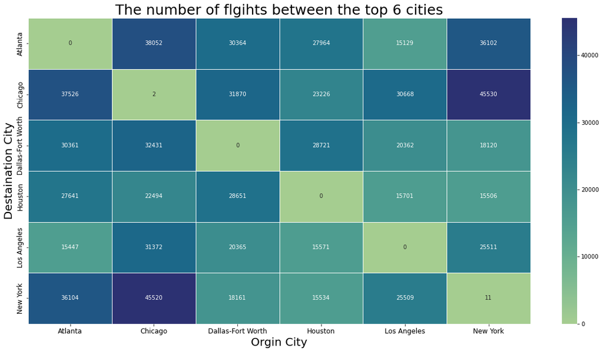

```python
plt.figure(figsize = (20,10))
sb.heatmap(data = no_of_flights,annot=True,fmt=".0f",cmap="crest",linewidth=1)
plt.xticks(np.arange(0.5,6,1),top_cities,fontsize = '12')
plt.yticks(np.arange(0.5,6,1),top_cities,fontsize = '12')
plt.title('The number of flgihts between the top 6 cities',fontsize = '25')
plt.xlabel('Orgin City',fontsize = '20')
plt.ylabel('Destaination City',fontsize = '20')
plt.show()
```

#### finally we can see that the number on-ward flights is almost equal to the number of return flights. Also we can see that most number of flights is between New York and Chicago also. they both are the only cities which have flights to them selfs (internal flights in the same city)

### Talk about some of the relationships you observed in this part of the investigation. How did the feature(s) of interest vary with other features in the dataset?

the weather played a big role in cancelled flights as we saw the month january ,December, and febraury have the highest number of cancelled flights due to the bad weather also we found that the largest number of flights between two cities was between Chicago and New York also we see that the number on-ward flights is almost equal to the number of return flights

### Did you observe any interesting relationships between the other features (not the main feature(s) of interest)?

Chicago is almost the highest of everything has the most number of flights to/from aslo have the highest number of cancelled and delayed flights also the long distances surprisingly tend to be less cancelled or delayed also although Chicago has the highest number of cancelled flights it doesn't have the hightest cancellation ratio